#### **To: King County Public Health**

#### **From: Sakshi Madan**

#### **Date: 12/13/2019**

#### **RE: Effectiveness of new food rating system on the performance of restaurants**

Food borne diseases cause 76 million illnesses in US each year, and almost half of all money spent on food is spent in restaurants. After the major food borne illness outbreak in 2014, King County residents asked for more information about restaurant inspections which led to the launch of new food safety rating system in January 2017. The major change was developing a window sign which has the latest rating for the restaurant and is visible to everyone. The new system is almost three years old and we wanted to analyze how restaurants are responding to it. We extracted the food inspection data from January 1st, 2006 until November 13th, 2019 which had 274,782 observations.

It was interesting and exciting to find the impact of the new rating system on performance of the restaurants. We found out that the median [^1] inspection score of restaurants in King County has improved(declined) since the introduction of new rating system but when we compared these scores between 5 major cities, Seattle, Bellevue, Kent, Renton and Federal Way (they have the maximum number of restaurants in decreasing order), we found out that Bellevue is the one with the worst(highest) inspection score. Other 4 cities have the same median inspection score as of now. We also found out that the percentage of restaurants with no violations have increased, with critical(red) violations have decreased and non critical(blue) violations did not have much impact since 2017 in King County. We analyzed this trend in those 5 cities again and found out there was an increase in percentage of non-violating restaurants in 2017 among all but since then, Seattle is the only city consistently following this pattern. Also, there was a decline in percentage of restaurants with critical(red) violations in 2017 among all except Renton but again since then, Seattle is the only city consistently following this pattern.

After the introduction of the new rating system, the median inspection score declined to 10 in 2017 and has been consistent since then.

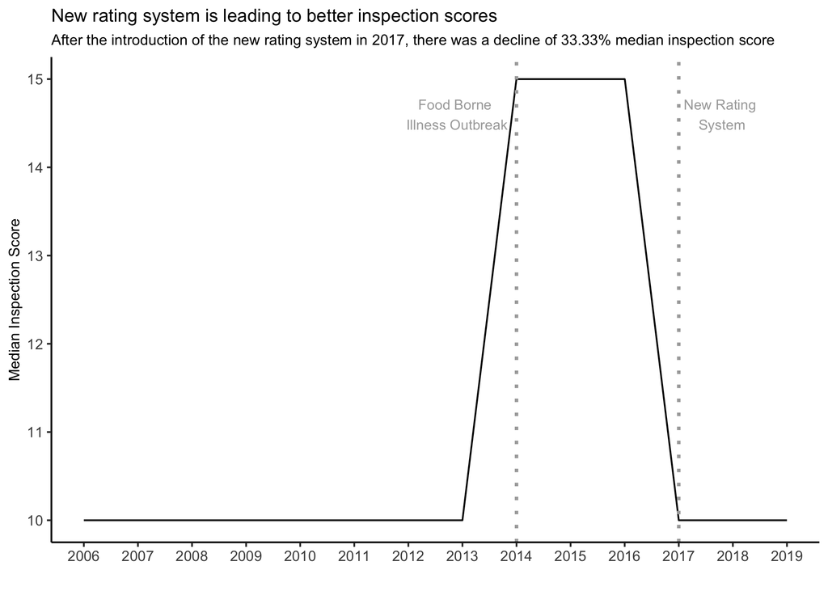

On comparing the score between major cities, it appeared that Bellevue is the outlier where the score has never declined since 2008. Median inspection score of all the cities is at 10 as of now, but that of Bellevue is at 15.

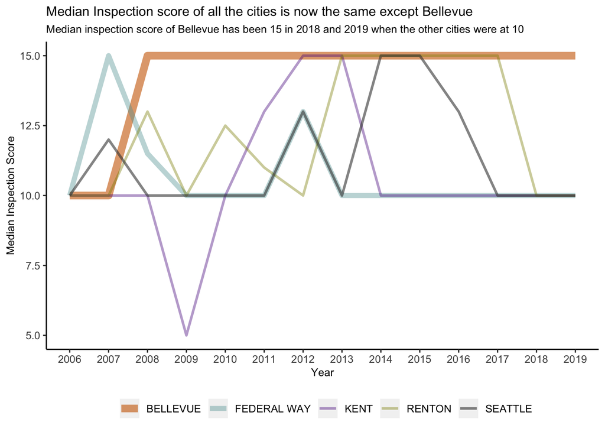

We found out that after the introduction of the new rating system in King County, restaurants with no violations increased to 44% in 2017 from 43% in 2016. They futher increased to 46% in 2018 and 50% in 2019 as shown in the graph below.

Also, restaurants with critical(red) violations decreased to 43% in 2017 from 45% in 2016. They futher decreased to 39% in 2018 and 35% in 2019.

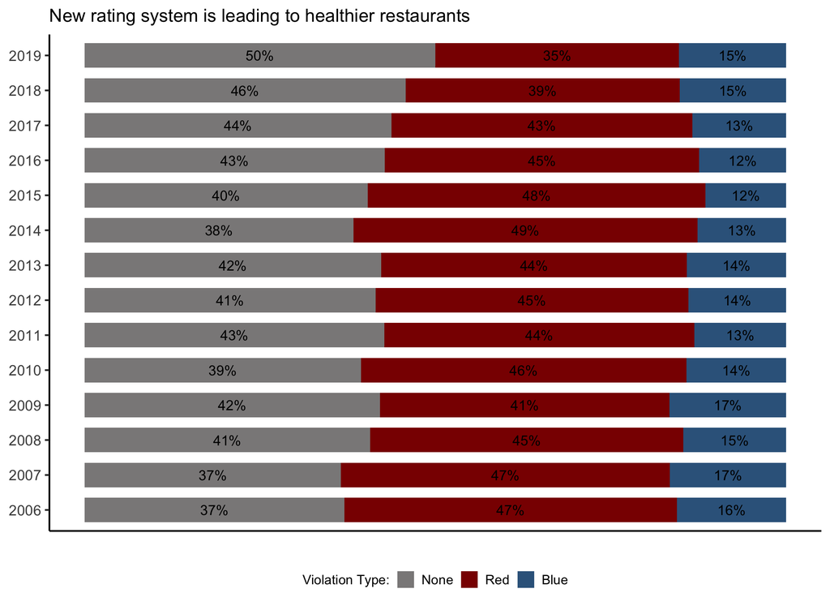

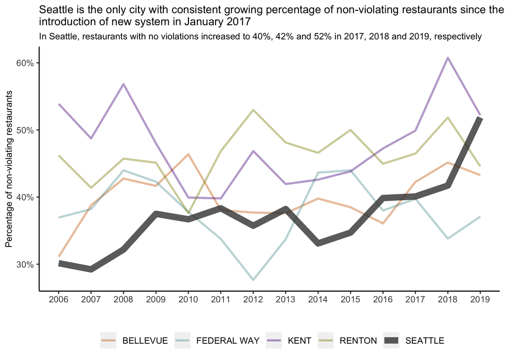

Similarly, Seattle is the only city which is consistently following the changed trend in critical(red) violation restaurants as well. As you can see in the graph below, in Seattle, restaurants with red violations declined to 46%, 42% and 33% in 2017, 2018 and 2019 respectively. Other than Renton, all the cities had a decline in 2017 but increased again in 2018 or 2019.

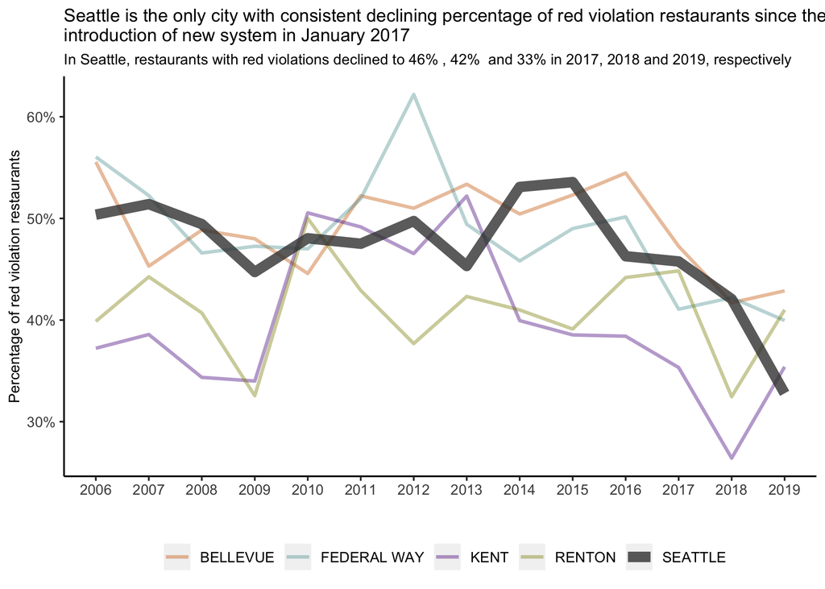

In conclusion, we can say that overall there is an improvement in performance of the restaurants in King County. On analyzing the performance between major 5 cities which have the maximum number of restaurants, we recommend conducting more consulations and education sessions in cities other than Seattle (especially Bellevue) to make sure the owners understand the rating system. We should also have more number of routine inspections per restaurant in those cities and make sure the restaurant owners are meeting all of the food safety standards. For a future project, we should investigate why restaurants with non-critical (blue) violations did not have an impact of new rating system. Also, we should investigate remaining cities in King County as well.

Please do not hesitate to contact me if you have questions or would like to discuss the analysis further, it is best to reach me at smadan@seattleu.edu.

Best regards,

Sakshi  
Data Analyst  
King County

[^1]: Median refers to the middle (half-above and half-below) of the data. We prefer to use median over mean (average) because median is not influenced by extreme values while mean is.